# Graphing CMU Varsity Swimming and Diving

# Introduction

This dataset was scraped from collegeswimming.com, which is widely used in the swimming community to track swims from around the NCAA, NAIA, and NJCAA. This site tracks *every* swim done at almost every collegiate meet, which allows us an incredibly granular look at collegiate swimming performance in the US. Each row of the dataset looks like the following:

`100 Y Fly|2014-12-06|49.96|2015|684`

This particular row was the 100 Yard Fly swam on December 6th, 2014 in a time of 49.96 during the 2014-2015 season. The 684 on the end is the “power points” awarded to the swim. “Power Points” are a standard method used by FINA, the international governing body of swimming, to standardize each event. You can see the full justification [here](http://archives.fina.org/H2O/docs/FINApoints/FINA_Points_Table_20150205.pdf), but the basic formula as follows:

$$\text{Power Points} = 1000 \times (\frac{\text{Record Time}}{\text{Actual Time}}) ^ 3$$
This is a standard way of comparing swims across multiple events. For example, this allows us to compare men to women, sprinters to distance swimmers, or if you really wanted to get crazy, backstrokers to breaststrokers. Very basically faster times garner larger scores, with a record-tying performance getting award exactly 1000 points.

This allows us to analytically approach questions which could in the past only be ballparked. What was the fastest swim of the season? How effective are taper cycles? What are a team’s best events? In the aggregate, we can compare entire teams, events, and even seasons.

# Visualization of everything as a whole

Let’s start with graphing every swim for every swimmer on the 2016-2017 roster

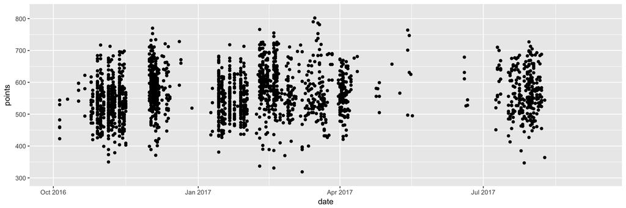